# Pilot Study — LC-MS Data Preprocessing

Peak detection, RT alignment, correspondence and gap filling (POS + NEG)

Author

CEMBIO-EURAC Team

Published

April 20, 2026

# Overview

**Study-specific instance**

This is the **combined** preprocessing for the **pilot study** (BμS device comparison), running positive and negative ionization modes simultaneously via `PosNegExp`. See `positive/` and `negative/` for the single-mode counterparts.

This document handles the preprocessing of LC-MS lipidomics data:

1. **Data Import** — Load raw `.mzML` data (local files, SQLite, or MetaboLights)
2. **Dataset Investigation** — BPC visualization and reference lipid EICs
3. **Chromatographic Peak Detection** — CentWave algorithm
4. **Retention Time Alignment** — QC-based peak group alignment
5. **Correspondence** — Feature grouping across samples
6. **Gap Filling** — Fill missing peak values

## The `PosNegExp` Framework

This workflow uses the `PosNegExp` S4 class system (defined in `R/pos_neg_exp.R`) to run both ionization modes in a single pipeline with minimal code duplication.

**Classes**

| Class | Wraps | Lifecycle |
| --- | --- | --- |
| `PosNegMsExp` | Two `MsExperiment` | From data load until `findChromPeaks()` |
| `PosNegXcmsExp` | Two `XcmsExperiment` | After `findChromPeaks()` onwards |

**Accessors** — extract individual modes at any point:

```r
posMode(mse)   # returns the positive-mode MsExperiment / XcmsExperiment
negMode(mse)   # returns the negative-mode counterpart
```

**Dispatched xcms functions** — called once, applied to both modes automatically:

```r
findChromPeaks(), filterRt(), groupChromPeaks(),
adjustRtime(), fillChromPeaks()
```

**`perMode()`** — pass mode-specific arguments to a dispatched function:

```r
filterRt(mse, rt = perMode(pos = c(10, 950), neg = c(10, 800)))
```

**Limitation** — `applyAdjustedRtime()` is not yet dispatched; it must be called explicitly per mode and the result re-wrapped:

```r
mse <- PosNegXcmsExp(applyAdjustedRtime(posMode(mse)),
                     applyAdjustedRtime(negMode(mse)))
```

## Folder Hierarchy

```
pilot_study/
├── LipidDatabase_R.xlsx
├── Preprocessing.qmd           # Step 1: This file (combined POS + NEG)
├── Annotation.qmd              # Step 2: Combined annotation
├── POS_NEG_merge.qmd           # Step 3: Combine POS + NEG results
├── positive/
│   ├── seq_pos_pilot.xlsx              # Sample sequence
│   ├── pos_lipid_reference_set.xlsx    # Reference lipids
│   ├── data/                           # .mzML files (symlink → POS_data/)
│   ├── objects/                        # Saved R objects (auto-generated)
│   └── figures/                        # Output figures (auto-generated)
└── negative/
    ├── seq_neg_pilot.xlsx              # Sample sequence
    ├── neg_lipid_reference_set.xlsx    # Reference lipids
    ├── data/                           # .mzML files (symlink → NEG_data/)
    ├── objects/                        # Saved R objects (auto-generated)
    └── figures/                        # Output figures (auto-generated)
```

**@SARA:**

maybe the folder structure can be simplified by having xlsx at the top level and folders `data`, `objects` and `figures` with subfolders `positive` and `negative` inside them, e.g. `data/positive` and `data/negative` (instead of `negative/data`, etc.)

## Required Input Files

Before running this workflow, ensure you have:

1. **Sequence files** `positive/seq_pos_pilot.xlsx` and `negative/seq_neg_pilot.xlsx`
2. **Reference lipid lists** `positive/pos_lipid_reference_set.xlsx` and `negative/neg_lipid_reference_set.xlsx`
3. **Raw data** (`.mzML` files) in `positive/data/` and `negative/data/`
4. **Lipid database** (`LipidDatabase_R.xlsx`) in this folder

# Configuration

```r
# ============================================================================
# PILOT STUDY CONFIGURATION
# ============================================================================

# Project root: relative path to the repository root (R/ helpers live there)
PROJECT_ROOT <- "../.."

# Study identifier
STUDY_ID <- "pilot"

# Prefix for saved objects — distinguishes PosNegExp PoC outputs from
# per-mode outputs (which use STUDY_ID alone as prefix)
SAVE_PREFIX <- "posNegExp"

# Data source: "local", "sqlite", or "metaboLights"
DATA_SOURCE <- "local"

# MetaboLights study ID (only used if DATA_SOURCE = "metaboLights")
MTBLS_ID <- "MTBLS10722"

# SQLite database paths (only used if DATA_SOURCE = "sqlite")
SQLITE_DB_POS <- NULL
SQLITE_DB_NEG <- NULL

# Number of CPU cores for parallel processing
CORES_NB <- 4

# Expected sample types (for validation)
EXPECTED_SAMPLE_TYPES <- c("QC", "M-VAMS", "W-DBS", "C-qDBS", "Plasma")

# Color palette for sample types
SAMPLE_TYPE_COLORS <- c(
  "QC"     = "#999999",
  "M-VAMS" = "#377EB8",
  "W-DBS"  = "#E41A1C",
  "C-qDBS" = "#4DAF4A",
  "Plasma" = "#984EA3"
)

# --- MetaboLights options (only used if DATA_SOURCE = "metaboLights") ---
MTBLS_ASSAY_POS <- "a_MTBLS10722_LC-MS_positive_reverse-phase_metabolite_profiling.txt"
MTBLS_ASSAY_NEG <- "a_MTBLS10722_LC-MS_negative_reverse-phase_metabolite_profiling.txt"

MTBLS_COLUMN_MAPPING <- list(
  sample_name     = "Sample Name",
  file_name       = "Raw Spectral Data File",
  sample_type     = "Factor Value[Sample type]",
  injection_index = "Comment[injection_index]"
)

MTBLS_FILTER_COLUMN <- "Factor Value[Cohort]"
MTBLS_FILTER_VALUE  <- "Cohort_study"
MTBLS_EXCLUDE_TYPES <- c("Blank")

# Retention time filter range (seconds) — may differ by polarity
RT_FILTER_POS <- c(10, 950)
RT_FILTER_NEG <- c(10, 800)

# Chromatographic peak detection parameters
PEAK_WIDTH   <- c(4, 8)  # min and max peak width in seconds
PPM          <- 10       # m/z tolerance in ppm
SN_THRESHOLD <- 2        # signal-to-noise threshold

# --- Per-mode input files ---
SEQ_FILE_POS <- "positive/seq_pos_pilot.xlsx"
SEQ_FILE_NEG <- "negative/seq_neg_pilot.xlsx"
IS_FILE_POS  <- "positive/pos_lipid_reference_set.xlsx"
IS_FILE_NEG  <- "negative/neg_lipid_reference_set.xlsx"
```

# Setup

## Load Packages and Helper Functions

```r
source(file.path(PROJECT_ROOT, "R/lipid_helpers.R"))
source(file.path(PROJECT_ROOT, "R/pos_neg_exp.R"))
source(file.path(PROJECT_ROOT, "R/create_sqlite_database.R"))
load_lipid_packages(verbose = TRUE)
```

## Setup Paths and Parallel Processing

```r
# Data directories (symlinked to POS_data/ and NEG_data/ at repo root)
DATA_DIR_POS <- "positive/data"
DATA_DIR_NEG <- "negative/data"

# Output directories
OBJECTS_DIR     <- "objects"                # combined POS+NEG objects (handover to Annotation.qmd)
OBJECTS_DIR_POS <- "positive/objects"       # mode-specific (EICs, etc.)
OBJECTS_DIR_NEG <- "negative/objects"
EIC_ISTD_DIR_POS <- "positive/figures/EIC_internal_standards"
EIC_ISTD_DIR_NEG <- "negative/figures/EIC_internal_standards"
PEAK_DET_DIR_POS <- "positive/figures/peak_detection_ref_lipid"
PEAK_DET_DIR_NEG <- "negative/figures/peak_detection_ref_lipid"

# Create output directories
for (.d in c(OBJECTS_DIR,
             OBJECTS_DIR_POS, OBJECTS_DIR_NEG,
             EIC_ISTD_DIR_POS, EIC_ISTD_DIR_NEG,
             PEAK_DET_DIR_POS, PEAK_DET_DIR_NEG)) {
  dir.create(.d, recursive = TRUE, showWarnings = FALSE)
}
rm(.d)

# Setup parallel processing
if (.Platform$OS.type == "unix") {
  register(MulticoreParam(CORES_NB))
} else {
  register(SnowParam(CORES_NB))
}
```

# Data Import

Load MS data based on the selected `DATA_SOURCE` option.

**Local mzML Files**

Load data from local `.mzML` files in `positive/data/` and `negative/data/`.

**SQLite Database**

Load from a pre-built SQLite database. Set `SQLITE_DB_POS` / `SQLITE_DB_NEG` in the Configuration section, or leave `NULL` to auto-generate from local files.

**MetaboLights**

Download data directly from MetaboLights (requires internet connection).

## Validate Input Files

```r
for (.pol in c("pos", "neg")) {
  .seq_file <- if (.pol == "pos") SEQ_FILE_POS else SEQ_FILE_NEG
  .is_file  <- if (.pol == "pos") IS_FILE_POS  else IS_FILE_NEG
  .data_dir <- if (.pol == "pos") DATA_DIR_POS else DATA_DIR_NEG

  validate_metadata(
    .seq_file,
    expected_sample_types = EXPECTED_SAMPLE_TYPES,
    data_dir = if (DATA_SOURCE == "local") .data_dir else NULL
  )
  validate_reference_lipids(.is_file)
}
rm(.pol, .seq_file, .is_file, .data_dir)
```

**📋 USER CHECKPOINT: Input Validation**

Check the output above for any **errors** or **warnings**. Fix any reported problems in your input files **before** continuing.

```r
.load_mode <- function(polarity, data_dir, seq_file) {
  seq_data <- read_xlsx(seq_file, col_names = TRUE) |> as.data.frame()
  seq_data$polarity <- polarity

  if (DATA_SOURCE == "local") {
    spectra_files <- file.path(data_dir, seq_data$file_name)
    missing_files <- spectra_files[!file.exists(spectra_files)]
    if (length(missing_files) > 0)
      stop("Missing files (", polarity, "):\n", paste(missing_files, collapse = "\n"))
    readMsExperiment(spectraFiles = spectra_files, sampleData = seq_data)

  } else if (DATA_SOURCE == "sqlite") {
    sqlite_db <- if (polarity == "pos") SQLITE_DB_POS else SQLITE_DB_NEG
    if (is.null(sqlite_db))
      sqlite_db <- file.path(data_dir, paste0(STUDY_ID, "_", polarity, ".sqlite"))
    if (!file.exists(sqlite_db)) {
      message("SQLite database not found. Creating from mzML files...")
      create_sqlite_database(
        study_id  = STUDY_ID,
        polarity  = polarity,
        seq_file  = seq_file,
        data_dir  = data_dir,
        output_db = sqlite_db
      )
    }
    load_from_sqlite(sqlite_db, seq_data)

  } else if (DATA_SOURCE == "metaboLights") {
    assay_name <- if (polarity == "pos") MTBLS_ASSAY_POS else MTBLS_ASSAY_NEG
    load_from_metaboLights(
      mtbls_id             = MTBLS_ID,
      assay_name           = assay_name,
      column_mapping       = MTBLS_COLUMN_MAPPING,
      filter_column        = MTBLS_FILTER_COLUMN,
      filter_value         = MTBLS_FILTER_VALUE,
      exclude_sample_types = MTBLS_EXCLUDE_TYPES,
      polarity             = polarity
    )
  } else {
    stop("Invalid DATA_SOURCE: '", DATA_SOURCE,
         "'. Use 'local', 'sqlite', or 'metaboLights'.")
  }
}

message("Loading positive mode data...")
mse_pos <- .load_mode("pos", DATA_DIR_POS, SEQ_FILE_POS)
message("Loading negative mode data...")
mse_neg <- .load_mode("neg", DATA_DIR_NEG, SEQ_FILE_NEG)
rm(.load_mode)
```

**`PosNegMsExp`: wrapping both modes**

`PosNegMsExp` holds both `MsExperiment` objects in a single container so that subsequent xcms calls automatically process positive and negative mode together. `posMode()` / `negMode()` extract each mode at any time.

```r
mse <- PosNegMsExp(mse_pos, mse_neg)
message("✓ Loaded ", length(posMode(mse)), " samples (pos) and ",
        length(negMode(mse)), " samples (neg)")
sampleData(posMode(mse))
```

```
DataFrame with 48 rows and 7 columns
              injection_index sample_name     file_name sample_type  ms_level
                    <numeric> <character>   <character> <character> <numeric>
QC_1_pos.mzML               1     QC1_POS QC_1_pos.m...          QC         1
D08M_pos.mzML               2        D08M D08M_pos.m...      M-VAMS         1
D05W_pos.mzML               3        D05W D05W_pos.m...       W-DBS         1
D10M_pos.mzML               4        D10M D10M_pos.m...      M-VAMS         1
D08W_pos.mzML               5        D08W D08W_pos.m...       W-DBS         1
...                       ...         ...           ...         ...       ...
D09M_pos.mzML              44        D09M D09M_pos.m...      M-VAMS         1
D01P_pos.mzML              45        D01P D01P_pos.m...      Plasma         1
D06M_pos.mzML              46        D06M D06M_pos.m...      M-VAMS         1
D07M_pos.mzML              47        D07M D07M_pos.m...      M-VAMS         1
QC_8_pos.mzML              48     QC8_POS QC_8_pos.m...          QC         1
                 polarity spectraOrigin
              <character>   <character>
QC_1_pos.mzML         pos /home/gaus...
D08M_pos.mzML         pos /home/gaus...
D05W_pos.mzML         pos /home/gaus...
D10M_pos.mzML         pos /home/gaus...
D08W_pos.mzML         pos /home/gaus...
...                   ...           ...
D09M_pos.mzML         pos /home/gaus...
D01P_pos.mzML         pos /home/gaus...
D06M_pos.mzML         pos /home/gaus...
D07M_pos.mzML         pos /home/gaus...
QC_8_pos.mzML         pos /home/gaus...
```

## Setup Color Palettes

```r
# Both modes share the same sample structure — derive palette from pos mode
palette_sample_type <- create_color_palette(
  posMode(mse),
  column        = "sample_type",
  custom_colors = SAMPLE_TYPE_COLORS
)

message("Color palette for sample_type:")
print(palette_sample_type)
```

```
       QC    M-VAMS     W-DBS    C-qDBS    Plasma
"#999999" "#377EB8" "#E41A1C" "#4DAF4A" "#984EA3"
```

# Dataset Investigation

## Chromatographic Data Visualization

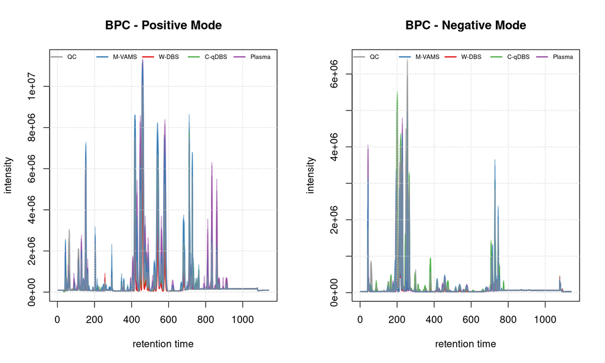

Base Peak Chromatogram — positive (left) and negative (right)

```r
par(mfrow = c(1, 2))
plot_bpc(posMode(mse), palette = palette_sample_type, main = "BPC - Positive Mode")
plot_bpc(negMode(mse), palette = palette_sample_type, main = "BPC - Negative Mode")
```

**📋 USER CHECKPOINT: RT Filter Range**

Examine the BPCs above and adjust `RT_FILTER_POS` / `RT_FILTER_NEG` in the Configuration section if needed. Current: POS **10–950** s, NEG **10–800** s.

**`perMode()`: mode-specific arguments in a single call**

`perMode(pos = ..., neg = ...)` is an S3 container that tells the dispatched method to apply different values to each mode. Here it passes distinct RT ranges to a single `filterRt()` call that operates on both modes simultaneously.

```r
mse <- filterRt(mse, rt = perMode(pos = RT_FILTER_POS, neg = RT_FILTER_NEG))
```

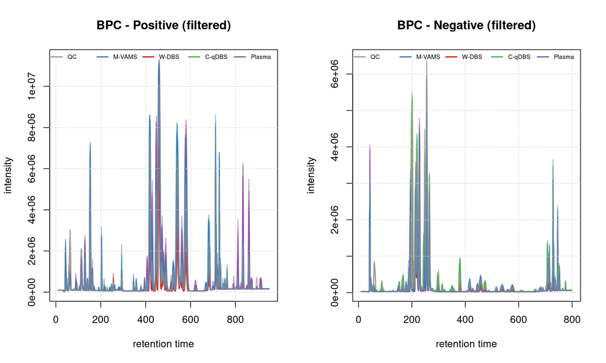

BPC after retention time filtering

```r
par(mfrow = c(1, 2))
plot_bpc(posMode(mse), palette = palette_sample_type, main = "BPC - Positive (filtered)")
plot_bpc(negMode(mse), palette = palette_sample_type, main = "BPC - Negative (filtered)")
```

## Reference Lipid EICs

```r
intern_standard_pos <- prepare_reference_lipids(
  IS_FILE_POS, rt_window_left = 30, rt_window_right = 15
)
intern_standard_neg <- prepare_reference_lipids(
  IS_FILE_NEG, rt_window_left = 30, rt_window_right = 20
)

eic_is_pos <- extract_is_eics(posMode(mse), intern_standard_pos)
eic_is_neg <- extract_is_eics(negMode(mse), intern_standard_neg)
fdata_pos  <- fData(eic_is_pos)
fdata_neg  <- fData(eic_is_neg)

message("Positive mode reference lipids:")
kable(intern_standard_pos[, c("short_name", "mz", "RT")], format = "pipe")
```

|  | short_name | mz | RT |
| --- | --- | --- | --- |
| CAR | CAR | 246.1700 | 48.00 |
| LysoPC | LysoPC | 496.3398 | 153.60 |
| dLysoPC | dLysoPC | 529.3994 | 164.58 |
| dLysoPE | dLysoPE | 487.3524 | 170.88 |
| LPC | LPC | 552.4024 | 254.40 |
| SM | SM | 701.5592 | 371.40 |
| dPG | dPG | 759.5875 | 387.60 |
| dSM | dSM | 738.6470 | 436.26 |
| PC | PC | 758.5694 | 465.60 |
| dPC | dPC | 753.6134 | 490.26 |
| dPE | dPE | 711.5664 | 510.18 |
| SM1 | SM1 | 759.6388 | 685.80 |
| dDG | dDG | 605.5844 | 700.80 |
| HexCer | HexCer | 812.6974 | 735.00 |
| TG | TG | 900.8015 | 838.20 |
| dTG | dTG | 829.7985 | 839.88 |
| dCE | dCE | 675.6779 | 927.60 |
| TG1 | TG1 | 880.8327 | 963.00 |

```r
message("Negative mode reference lipids:")
kable(intern_standard_neg[, c("short_name", "mz", "RT")], format = "pipe")
```

|  | short_name | mz | RT |
| --- | --- | --- | --- |
| LPInew | LPInew | 619.2889 | 98.40 |
| LPC | LPC | 580.3619 | 153.60 |
| LPE | LPE | 452.2782 | 160.20 |
| dLPC | dLPC | 587.4058 | 163.20 |
| dLPE | dLPE | 485.3378 | 169.80 |
| LPI | LPI | 599.3202 | 170.40 |
| LPCnew | LPCnew | 582.3776 | 206.40 |
| dFA | dFA | 286.4275 | 211.26 |
| dMG | dMG | 422.3503 | 219.00 |
| FA | FA | 339.3268 | 380.40 |
| dPI | dPI | 828.5625 | 382.20 |
| PInew | PInew | 861.5498 | 447.60 |
| PCnew2 | PCnew2 | 816.5760 | 474.60 |
| PC | PC | 866.5916 | 487.20 |
| dPC | dPC | 811.6198 | 493.20 |
| dPE | dPE | 709.5517 | 512.40 |
| PI | PI | 863.5655 | 520.20 |
| PE | PE | 716.5236 | 589.20 |
| Pcnew | Pcnew | 844.6073 | 600.60 |
| HexCer | HexCer | 868.6883 | 718.20 |
| Cer | Cer | 710.6667 | 761.40 |

Reference lipids for RT correction

```r
plot_eic_batch(eic_is_pos, fdata_pos, palette = palette_sample_type,
               output_dir = EIC_ISTD_DIR_POS)
plot_eic_batch(eic_is_neg, fdata_neg, palette = palette_sample_type,
               output_dir = EIC_ISTD_DIR_NEG)
```

**📋 USER CHECKPOINT: Reference Lipid EICs**

Check the EIC plots saved in **positive/figures/EIC_internal_standards** (positive) and **negative/figures/EIC_internal_standards** (negative).

- The red dashed line indicates the expected RT
- Each peak should be detected in most/all samples
- Note any compounds with poor signal or unexpected RT shifts
- Note peak width to inform `PEAK_WIDTH`

# Data Preprocessing

## Chromatographic Peak Detection

```r
param_pd <- CentWaveParam(
  peakwidth          = PEAK_WIDTH,
  ppm                = PPM,
  integrate          = 2,
  snthresh           = SN_THRESHOLD,
  firstBaselineCheck = FALSE
)
param_pd
```

```
Object of class:  CentWaveParam
 Parameters:
 - ppm: [1] 10
 - peakwidth: [1] 4 8
 - snthresh: [1] 2
 - prefilter: [1]   3 100
 - mzCenterFun: [1] "wMean"
 - integrate: [1] 2
 - mzdiff: [1] -0.001
 - fitgauss: [1] FALSE
 - noise: [1] 0
 - verboseColumns: [1] FALSE
 - roiList: list()
 - firstBaselineCheck: [1] FALSE
 - roiScales: numeric(0)
 - extendLengthMSW: [1] FALSE
 - verboseBetaColumns: [1] FALSE
```

**Dispatched xcms functions**

`findChromPeaks()`, `groupChromPeaks()`, `adjustRtime()`, and `fillChromPeaks()` are all dispatched on `PosNegXcmsExp`. A single call processes both modes in sequence; the result is automatically re-wrapped in a `PosNegXcmsExp`.

```r
mse <- findChromPeaks(mse, param = param_pd, chunkSize = CORES_NB)

# Update EICs with detected peaks for each mode
eic_is_pos <- extract_is_eics(posMode(mse), intern_standard_pos)
fData(eic_is_pos) <- fdata_pos
eic_is_neg <- extract_is_eics(negMode(mse), intern_standard_neg)
fData(eic_is_neg) <- fdata_neg
```

```r
for (.pol in c("pos", "neg")) {
  .mse <- if (.pol == "pos") posMode(mse) else negMode(mse)
  df <- data.frame(
    sample_name = sampleData(.mse)$sample_name,
    peak_count  = as.integer(table(chromPeaks(.mse)[, "sample"]))
  )
  cat("\n\n**", toupper(.pol), "mode — peaks per sample**\n\n", sep = "")
  cat(knitr::kable(df, format = "pipe"), sep = "\n")
  cat("\n")
}
```

**POSmode — peaks per sample**

| sample_name | peak_count |
| --- | --- |
| QC1_POS | 23275 |
| D08M | 20786 |
| D05W | 16289 |
| D10M | 22331 |
| D08W | 15333 |
| D04C | 21790 |
| QC2_POS | 22838 |
| D02M | 21162 |
| D03M | 21557 |
| D06P | 16365 |
| D09P | 14990 |
| D02W | 15080 |
| D04W | 15535 |
| QC3_POS | 22646 |
| D05C | 21052 |
| D10C | 21722 |
| D01C | 20873 |
| D07C | 19880 |
| D03W | 15600 |
| D03P | 17056 |
| QC4_POS | 22288 |
| D04P | 15435 |
| D03C | 21613 |
| D09W | 14072 |
| D01M | 19885 |
| D01W | 14785 |
| D07P | 15632 |
| QC5_POS | 21664 |
| D06W | 15550 |
| D10W | 13935 |
| D08P | 15257 |
| D05P | 15184 |
| D06C | 20758 |
| D10P | 14714 |
| QC6_POS | 21686 |
| D02C | 20627 |
| D04M | 19343 |
| D02P | 15072 |
| D09C | 19336 |
| D07W | 13343 |
| D05M | 20352 |
| QC7_POS | 21442 |
| D08C | 21261 |
| D09M | 19584 |
| D01P | 14599 |
| D06M | 21794 |
| D07M | 20758 |
| QC8_POS | 22083 |

**NEGmode — peaks per sample**

| sample_name | peak_count |
| --- | --- |
| QC1_POS | 19154 |
| D08M | 13505 |
| D05W | 10359 |
| D10M | 14516 |
| D08W | 10538 |
| D04C | 19026 |
| QC2_POS | 19254 |
| D02M | 13774 |
| D03M | 14201 |
| D06P | 11140 |
| D09P | 10092 |
| D02W | 10146 |
| D04W | 10569 |
| QC3_POS | 20018 |
| D05C | 19495 |
| D10C | 19455 |
| D01C | 18973 |
| D07C | 18711 |
| D03W | 10475 |
| D03P | 10417 |
| QC4_POS | 18967 |
| D04P | 10775 |
| D03C | 19297 |
| D09W | 9999 |
| D01M | 13912 |
| D01W | 10657 |
| D07P | 10667 |
| QC5_POS | 19070 |
| D06W | 10177 |
| D10W | 9865 |
| D08P | 10703 |
| D05P | 10719 |
| D06C | 19018 |
| D10P | 10820 |
| QC6_POS | 19701 |
| D02C | 19567 |
| D04M | 13650 |
| D02P | 10047 |
| D09C | 18418 |
| D07W | 10253 |
| D05M | 14799 |
| QC7_POS | 20178 |
| D08C | 20266 |
| D09M | 14238 |
| D01P | 10633 |
| D06M | 15038 |
| D07M | 14707 |
| QC8_POS | 20040 |

```r
rm(.pol, .mse, df)
```

```r
plot_eic_batch(eic_is_pos, fdata_pos, palette = palette_sample_type,
               output_dir = PEAK_DET_DIR_POS)
plot_eic_batch(eic_is_neg, fdata_neg, palette = palette_sample_type,
               output_dir = PEAK_DET_DIR_NEG)
```

**📋 USER CHECKPOINT: Peak Detection Results**

Review the plots in **positive/figures/peak_detection_ref_lipid** (positive) and **negative/figures/peak_detection_ref_lipid** (negative).

- Each peak should be detected in most samples
- Check that peaks are not merged incorrectly
- Adjust `PEAK_WIDTH`, `PPM`, or `SN_THRESHOLD` if needed

## Retention Time Alignment

```r
# Both modes share the same sample structure — use pos to derive groups
QC_samples <- sampleData(posMode(mse))$sample_type == "QC"

param_c <- PeakDensityParam(
  sampleGroups = QC_samples,
  minFraction  = 0.9,
  binSize      = 0.01,
  ppm          = PPM,
  bw           = 2
)
mse <- groupChromPeaks(mse, param = param_c)

subset_idx  <- which(QC_samples)
param_align <- PeakGroupsParam(
  minFraction  = 0.9,
  extraPeaks   = 50,
  span         = 0.5,
  subsetAdjust = "average",
  subset       = subset_idx
)

mse <- adjustRtime(mse, param = param_align)
```

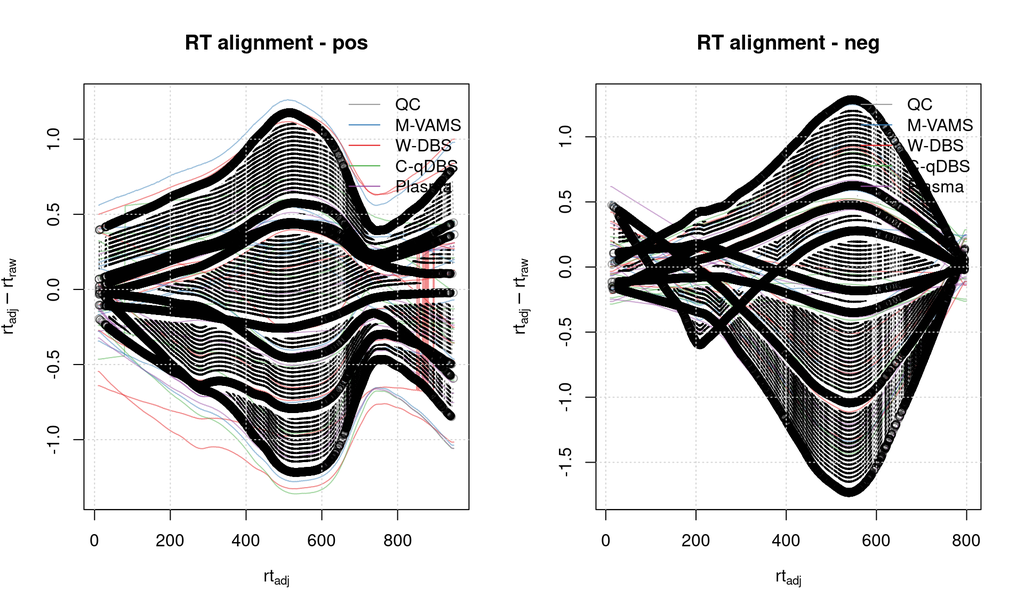

Retention time alignment (positive left, negative right)

```r
par(mfrow = c(1, 2))
for (.pol in c("pos", "neg")) {
  .mse       <- if (.pol == "pos") posMode(mse) else negMode(mse)
  col_sample <- get_sample_colors(sampleData(.mse)$sample_type, palette_sample_type)
  plotAdjustedRtime(.mse, col = paste0(col_sample, "80"), peakGroupsPch = 1,
                    main = paste("RT alignment -", .pol))
  grid()
  legend("topright", col = palette_sample_type,
         legend = names(palette_sample_type), lty = 1, bty = "n")
}
```

```r
rm(.pol, .mse, col_sample)
```

**`applyAdjustedRtime()`: explicit per-mode call**

`applyAdjustedRtime()` is not yet an S4 generic dispatched on `PosNegXcmsExp`. It must be called on each mode separately and the results re-wrapped manually.

```r
mse_raw <- dropAdjustedRtime(mse)
mse <- PosNegXcmsExp(
  applyAdjustedRtime(posMode(mse)),
  applyAdjustedRtime(negMode(mse))
)
```

## Correspondence Analysis

```r
group_mse <- sampleData(posMode(mse))$sample_type
group_mse[group_mse == "QC"] <- NA
group_mse <- as.factor(group_mse)

param_cor <- PeakDensityParam(
  sampleGroups = group_mse,
  minFraction  = 0.5,
  binSize      = 0.01,
  ppm          = PPM,
  bw           = 2
)

mse <- groupChromPeaks(mse, param = param_cor)

for (.pol in c("pos", "neg")) {
  .mse <- if (.pol == "pos") posMode(mse) else negMode(mse)
  message(.pol, " correspondence: ", nrow(featureDefinitions(.mse)), " features")
}
rm(.pol, .mse)
```

## Gap Filling

```r
na_before <- list(
  pos = sum(is.na(featureValues(posMode(mse)))) /
          length(featureValues(posMode(mse))) * 100,
  neg = sum(is.na(featureValues(negMode(mse)))) /
          length(featureValues(negMode(mse))) * 100
)

mse <- fillChromPeaks(mse, param = ChromPeakAreaParam(), chunkSize = CORES_NB)

for (.pol in c("pos", "neg")) {
  .mse     <- if (.pol == "pos") posMode(mse) else negMode(mse)
  na_after <- sum(is.na(featureValues(.mse))) / length(featureValues(.mse)) * 100
  message(.pol, " gap filling: ", round(na_before[[.pol]], 1),
          "% -> ", round(na_after, 1), "% NA")
  if (na_before[[.pol]] > 50)
    warning("High initial NA % in ", .pol, " mode (",
            round(na_before[[.pol]], 1), "%).")
}
rm(.pol, .mse, na_after)
```

**Gap Filling Guidance**

- **< 30% NA before filling**: Good — typical for well-detected features
- **30-50% NA before filling**: Acceptable — may indicate lower abundance compounds
- **> 50% NA before filling**: Review peak detection parameters or sample quality

## Extract Results and Save

```r
mse_pos <- posMode(mse)
mse_neg <- negMode(mse)

res_pos <- quantify(mse_pos, method = "sum", filled = FALSE)
assays(res_pos)$raw_filled <- featureValues(mse_pos, method = "sum", filled = TRUE)

res_neg <- quantify(mse_neg, method = "sum", filled = FALSE)
assays(res_neg)$raw_filled <- featureValues(mse_neg, method = "sum", filled = TRUE)
```

```r
validate_result(res_pos, assay_name = "raw", min_features = 50)
validate_result(res_neg, assay_name = "raw", min_features = 50)
```

```r
# For SQLite-backed experiments, materialise spectra into memory before
# serialising — the file-backed backend cannot be restored from an RDS.
if (DATA_SOURCE == "sqlite") {
  .swap <- function(xcms_exp) {
    spectra(xcms_exp) <- setBackend(spectra(xcms_exp), MsBackendMemory())
    xcms_exp
  }
  mse <- PosNegXcmsExp(.swap(posMode(mse)), .swap(negMode(mse)))
  rm(.swap)
}

res_pos@metadata <- list()
res_neg@metadata <- list()

saveRDS(mse,
        file.path(OBJECTS_DIR, paste0(SAVE_PREFIX, "_preprocessed_mse.rds")))
saveRDS(PosNegSumExp(res_pos, res_neg),
        file.path(OBJECTS_DIR, paste0(SAVE_PREFIX, "_preprocessed_res.rds")))

message("✓ Saved PosNegXcmsExp → ",
        file.path(OBJECTS_DIR, paste0(SAVE_PREFIX, "_preprocessed_mse.rds")))
message("✓ Saved PosNegSumExp  → ",
        file.path(OBJECTS_DIR, paste0(SAVE_PREFIX, "_preprocessed_res.rds")))
message("\nNext step: Run Annotation.qmd for RT correction and annotation.")
```

# Reference

1. Metabonaut tutorial: https://rformassspectrometry.github.io/Metabonaut/articles/a-end-to-end-untargeted-metabolomics.html#retention-time-alignment